# Chapitre 3 : Plans de sondage à probabilités inégales

```r
require(sampling)
require(survey)
require("tidyverse") ###pour ggplot
library('sampling')
library(ggplot2)
```

# 1 Lecture des données

```r
data(rec99)
attach(rec99)
```

```r
set.seed(123456)
```

# 2 Plan multinomial

Taille de la population

```r
N<-length(LOG)
N
```

```
## [1] 554
```

```r
tLOG<-sum(LOG)
pk<-LOG/tLOG # Probailité de ..
```

Taille de l’echantilon

```r
m<-70
```

## 2.1 Estimation d’un total et de la variance de l’estimateur HT

```r
R<-UPmultinomial(m*pk)
sum(R)
```

```
## [1] 70
```

Indices des indivisus selectionnés dans l’echantillon

```r
s<-rep((1:N)[R!=0], R[R!=0])
s
```

```
##  [1]   9  15  27  32  32  39  39  52  73  73  98 106 107 123 124 148 154 167 173
## [20] 176 186 195 211 214 235 250 261 266 271 276 281 290 311 314 324 357 371 389
## [39] 393 402 403 414 419 419 419 419 423 426 434 434 439 460 465 465 466 480 488
## [58] 491 491 512 512 518 525 527 531 546 546 548 549 550
```

Calcul de l’estimateur de Hansen-Hurwitz du total de logements vacants

```r
LOGVAC.HH<-sum((R*LOGVAC/pk))/m
LOGVAC.HH
```

```
## [1] 10265.59
```

Calcul de la variance de l’estimateur de Hansen-Hurwitz du total de logements vacants

```r
var.est.HH<-sum(R*(LOGVAC/pk-LOGVAC.HH)^2)/(m*(m-1))
var.est.HH
```

```
## [1] 565123.3
```

Intervalle de confiance à 95% pour le total de logements vacants

```r
c(LOGVAC.HH-qnorm(0.975)*sqrt(var.est.HH),LOGVAC.HH+qnorm(0.975)*sqrt(var.est.HH))
```

```
## [1]  8792.191 11738.985
```

Valeur réelle du nombre de logements vacants

```r
sum(LOGVAC)
```

```
## [1] 10768
```

## 2.2 Estimation à l’aide la fonction svydesign

On ajoute une colonne contenant le poid de chaque observation au dataframe. On stocke ensuite dans *recs* les observations selectionnées lors de l’echantillonnage.

```r
recs<-cbind.data.frame(rec99, poids=1/(m*pk))
recs<-recs[s,]
```

Initialisation de la fonction svydesign

```r
design.pps<-svydesign(id=~1, weights=recs$poids, data=recs)
```

Estimateur du total de logements vacants

```r
res.pps<-svytotal(~LOGVAC, design.pps)
print(ftable(res.pps),digits=5)
```

```
##                   LOGVAC
## LOGVAC 10265.59   751.75
```

# 3 Calcul des probabilités d’inclusion d’ordre 1

Taille souhaitée de l’échantillon

```r
n<-70
```

Calcule des probabilités d’inclusion. Il ya donc 7 communes pour les quelles les probabilités d’inclusion sont égales à 1.

```r
pik<-inclusionprobabilities(LOG,n)
rec99[pik==1,c(2,5)]
```

```
##          COMMUNE  LOG
## 32      AUTERIVE 2777
## 39  BAGNERES-DE- 4490
## 106 CASTELGINEST 2874
## 403 PORTET-SUR-G 3473
## 419        REVEL 3894
## 455   SAINT-JEAN 3288
## 549 VILLENEUVE-T 3189
```

# 4 Plan de Poisson

Echantillon de taille n=70, calcul des probabilités d’inclusion par la fonction **inclusionprobabilities**

```r
n<-70
pik<-inclusionprobabilities(LOG,n)
```

On tire l’échantillon s

```r
s<-UPpoisson(pik)
sum(s)
```

```
## [1] 70
```

On verifie que l’esperance de **ns** la taille de l’échantillon est bien 70 .

```r
ns<-replicate(10000,
              {ss<-UPpoisson(pik)
              sum(ss)})
mean(ns)
```

```
## [1] 69.9471
```

Calcule de l’estimateur de Horvitz-Thompson du total des logements vacants (la variable d’intérêt ys) à l’aide de la fonction HTestimator(.), son estimateur de la variance

```r
ys<-LOGVAC[s==1]
piks<-pik[s==1]
LOGVAC.HT<-HTestimator(ys,piks)
LOGVAC.HT
```

```
##          [,1]
## [1,] 11160.61
```

```r
var.est.HT<-sum((1-piks)*(ys^2)/(piks^2))
var.est.HT
```

```
## [1] 1480315
```

```r
pikl<-outer(pik,pik,"*")
diag(pikl)<-pik
pikls<-pikl[s==1,s==1]
varHT(ys,pikls,method=1)
```

```
## [1] 1480315
```

Intervalle de confiance à 95% pour le total de la population

```r
c(LOGVAC.HT-qnorm(0.975)*sqrt(var.est.HT),LOGVAC.HT+qnorm(0.975)*sqrt(var.est.HT))
```

```
## [1]  8775.956 13545.262
```

```r
sum(LOGVAC)
```

```
## [1] 10768
```

# 5 Plan systèmatique à prob. inégales

On veut tirer un échantillon s, avec **n = 70** à l’aide du plan systématique et estimer le total de logements vacants à l’aide de l’estimateur de **Horvitz-Thompson** (fonction HTestimator(.)).

La fonction UPsystematicpi2(.) calcule les probabilités d’inclusion d’ordre deux pour ce plan

```r
n<-70
pikl<-UPsystematicpi2(pik)
sum(pikl==0)
```

```
## [1] 231304
```

On tire l’echantillon s

```r
s<-UPsystematic(pik)
sum(s)
```

```
## [1] 70
```

Indices **ys**, probabilités d’inclusion du premier ordre **piks**, et probabilités d’inclusion du second ordre **pikls** des individus selectionnés

```r
ys<-LOGVAC[s==1]
piks<-pik[s==1]
pikls<-pikl[s==1,s==1]
```

Pour pallier à ce problème, l’estimateur de Deville est appliqué. Cet estimateur de la variance biaisé est obtenu grâce à la fonction varest(.).

```r
LOGVAC.HT<-HTestimator(ys,piks) # Estimateur HT du total
LOGVAC.HT
```

```
##         [,1]
## [1,] 11924.8
```

```r
varHT(ys,pikls,method=2)
```

```
## [1] -23119765
```

```r
var.approx.HT<-varest(ys,pik=piks)
var.approx.HT
```

```
## [1] 684313.2
```

# 6 Plan de Poisson conditionnel à la taille

Les probabilités πk sont proportionnelles à la variable LOG, n = 70 et y est la variable LOGVAC. Les probabilités d’inclusion d’ordre un pour ce plan ne sont pas égales aux probabilités (πk) utilisées pour tirer un échantillon à l’aide de la fonction UPmaxentropy(.).

Les robabilités d’inclusion d’ordre un pour ce plan sont calculés à l’aide de la fonction UPMEpiktildefrompik(.).

Les probabilités d’inclusion d’ordre deux pour le plan de Poisson conditionnel à la taille sont calculées à l’aide de la fonction UPmaxentropypi2(.).

Au niveau de l’échantillon, les probabilités d’inclusion d’ordre un et deux sont calculées respectivement à l’aide de piks<-piktilde[s==1] et pikls<-pikl[s==1,s==1].

```r
set.seed(12345)
s<-UPmaxentropy(pik)
piktilde<-pik
piktilde[pik!=1]<-UPMEpiktildefrompik(pik[pik!=1])
ys<-LOGVAC[s==1]
piktildes<-piktilde[s==1]
pikltilde<-UPmaxentropypi2(pik)
pikltildes<-pikltilde[s==1,s==1]
```

Calcul de l’estimateur de Horvitz-Thompson, sa variance estimée

```r
LOGVAC.HT<-HTestimator(ys,piktildes)
LOGVAC.HT
```

```
##          [,1]
## [1,] 10747.63
```

```r
V.HT<-varHT(ys,pikltildes,method=2)
V.HT
```

```
## [1] 537803.7
```

Intervalle de confiance à 95% du total de la population

```r
c(LOGVAC.HT-qnorm(0.975)*sqrt(V.HT),
  LOGVAC.HT+qnorm(0.975)*sqrt(V.HT))
```

```
## [1]  9310.284 12184.967
```

```r
sum(LOGVAC)
```

```
## [1] 10768
```

# 7 Simulations de Monte-Carlo avec plans diff

Taille de la population **N**, de l’échantillon **n**, et nombre de simulation **n.sim = 10 000**

```r
N<-nrow(rec99)
n<-70
n.sim<-10000
```

y = Nombre de logement vacant et on calcul les probailités d’incluson pour le plan simple, le plan de poisson et le plan systématique.

```r
y<-LOGVAC
pik<-inclusionprobabilities(LOG,n)
pik1<-rep(n/N,N)
```

On réalise les simulations des l’estimateur de Horvitz-Thompson pour chaque plan

```r
r1<-replicate(n.sim, srswor(n,N))
ht1<-apply(r1, 2, FUN=function(s,y,pik1)
                  HTestimator(y[s==1],pik1[s==1]),y,pik1)
r2<-replicate(n.sim, UPpoisson(pik))
ht2<-apply(r2, 2, FUN=function(s,y,pik)
                  HTestimator(y[s==1],pik[s==1]),y,pik)
r3<-replicate(n.sim, UPsystematic(pik))
ht3<-apply(r3, 2, FUN=function(s,y,pik)
                  HTestimator(y[s==1],pik[s==1]),y,pik)
```

Boîtes à moustaches des estimateurs de Horvitz-Thompson correspondants aux plans simple, Poisson et systématique

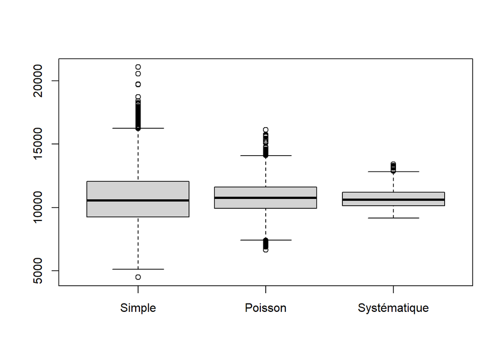

```r
boxplot(ht1,ht2,ht3, names = c('Simple', 'Poisson', 'Systématique'))
```

# Utilisation de la fonction sample() à probabilités inégales

## 7.1 Avec sample()

```r
set.seed(12345)

n.sim<-10000
prob<-matrix(0,nrow=n.sim,ncol=N)
for(i in 1:n.sim)
{
s<-sample(1:N,n,p=pik)
prob[i,1:N]<-(1:N %in% s)
}
pik_estimées<-apply(prob,2,mean)
max(pik_estimées/pik)
```

```
## [1] 1.451524
```

## 7.2 Avec UPpoisson()

```r
set.seed(12345)

prob<-matrix(0,nrow=n.sim,ncol=N)
for(i in 1:n.sim)
{
s<-UPpoisson(pik)
prob[i,1:N]<-s
}
pik_estimées1<-apply(prob,2,mean)
max(pik_estimées1/pik)
```

```
## [1] 1.283919
```

Boîtes à moustaches des probabilités estimées avec la fonction sample(.) et probabilités réelles

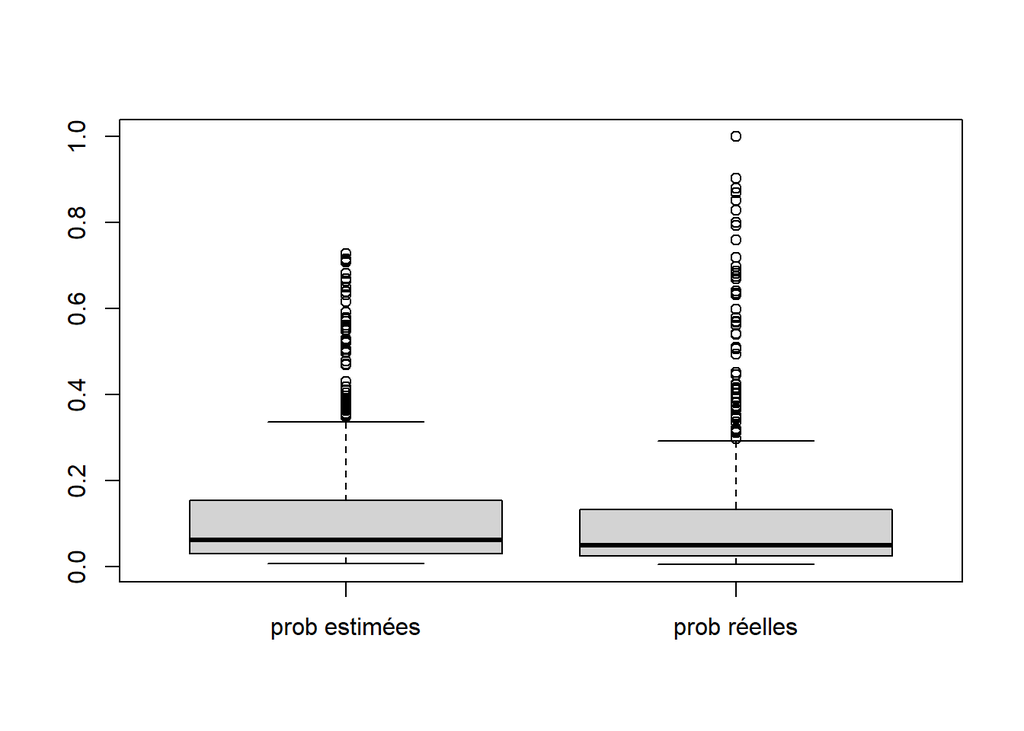

```r
boxplot(pik_estimées,pik, names = c('prob estimées', 'prob réelles'))
```

Boîtes à moustaches des probabilités estimées avec la fonction UPpoisson(.) et probabilités réelles

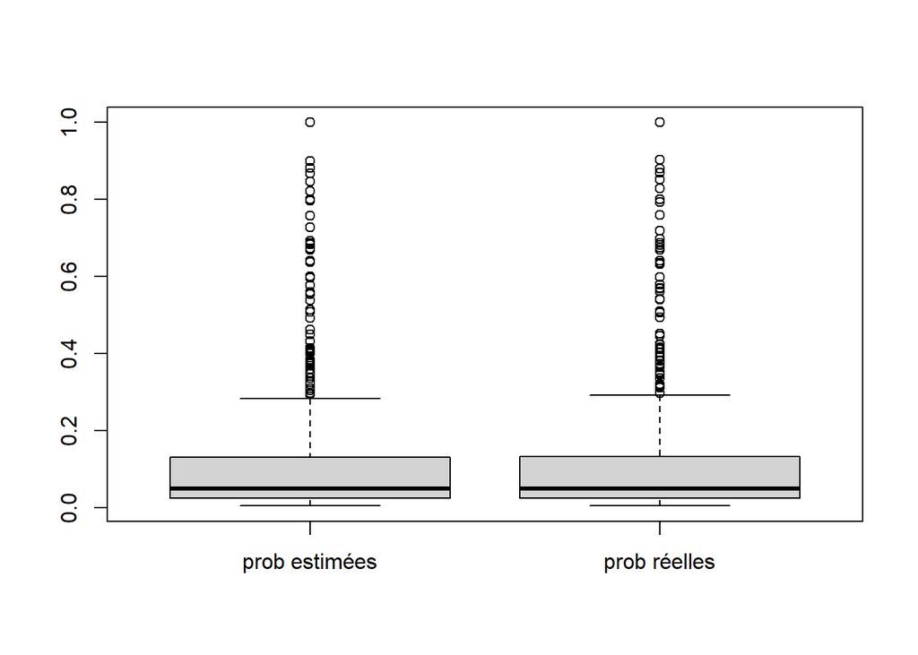

```r
boxplot(pik_estimées1,pik,names = c('prob estimées', 'prob réelles'))
```